# Practical Machine Learning Final Project

Yuchen Ding

1/3/2021

## Executive Summary

The goal of this project is to predict the manner (5 different ways) of 6 participants have performed, by using data collected from accelerometers on the belt, forearm, arm, and dumbell. Three different models (decision tree, random forest, and GBM) were used to train the data and the one with best predicting accuracy was selected to predict the 20 test cases available in the test data.

## Background

Using devices such as Jawbone Up, Nike FuelBand, and Fitbit it is now possible to collect a large amount of data about personal activity relatively inexpensively. These type of devices are part of the quantified self movement – a group of enthusiasts who take measurements about themselves regularly to improve their health, to find patterns in their behavior, or because they are tech geeks. One thing that people regularly do is quantify how much of a particular activity they do, but they rarely quantify how well they do it. In this project, your goal will be to use data from accelerometers on the belt, forearm, arm, and dumbell of 6 participants. They were asked to perform barbell lifts correctly and incorrectly in 5 different ways. More information is available from the website here: http://web.archive.org/web/20161224072740/http:/groupware.les.inf.puc-rio.br/har (see the section on the Weight Lifting Exercise Dataset).

## Preparing the Environment

```r
setwd("E:/study/coursera/Data Science Specialization/Course 8 Practical Machine Learning")
library(ggplot2)
library(caret)
library(rpart)
library(rpart.plot)
library(rattle)
library(corrplot)
library(randomForest)
library(gbm)
```

## Loading the Data

```r
trainUrl <- "https://d396qusza40orc.cloudfront.net/predmachlearn/pml-training.csv"
validUrl <- "https://d396qusza40orc.cloudfront.net/predmachlearn/pml-testing.csv"
trainRaw <- read.csv(url(trainUrl))
validRaw <- read.csv(url(validUrl))
dim(trainRaw)
```

```
## [1] 19622   160
```

```r
dim(validRaw)
```

```
## [1]  20 160
```

## Data Preprocessing

#### Split the Data for Training

```r
set.seed(7)
inTrain <- createDataPartition(trainRaw$classe, p = 0.7, list = F)
trainingRaw <- trainRaw[inTrain, ]
testingRaw <- trainRaw[-inTrain, ]
dim(trainingRaw)
```

```
## [1] 13737   160
```

```r
dim(testingRaw)
```

```
## [1] 5885  160
```

#### Removing Variables with lots of NAs (> 90 %)

```r
manyNAs <- sapply(trainingRaw, function(x) mean(is.na(x))) > 0.9
training <- trainingRaw[, manyNAs == F]
testing <- testingRaw[, manyNAs == F]
dim(training)
```

```
## [1] 13737    93
```

```r
dim(testing)
```

```
## [1] 5885   93
```

#### Removing Variables with Little Impact on the Outcome

```r
training <- training[, -c(1:6)]
testing <- testing[, -c(1:6)]
dim(training)
```

```
## [1] 13737    87
```

```r
dim(testing)
```

```
## [1] 5885   87
```

#### Removing Variables with Near Zero Variance

```r
nzVar <- nearZeroVar(training)
training <- training[, -nzVar]
testing <- testing[, -nzVar]
dim(training)
```

```
## [1] 13737    54
```

```r
dim(testing)
```

```
## [1] 5885   54
```

## Correlation Analysis

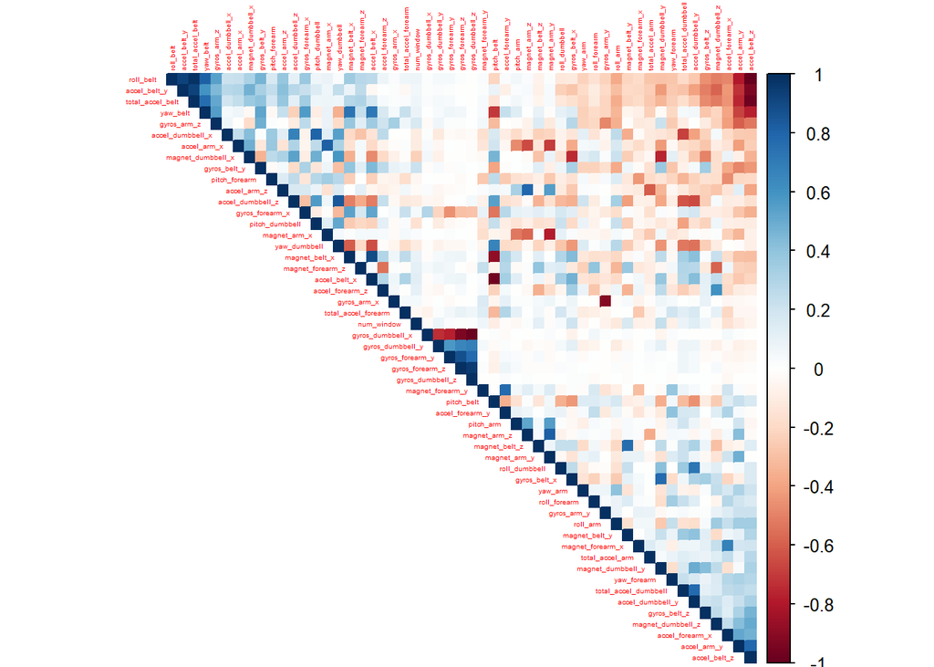

```r
corMatrix <- cor(training[, -54])
corrplot(corMatrix, order = "FPC", method = "color", type = "upper", tl.cex = 0.3)
```

As most of the variables are less-correlated, all 53 variables will be used for building the ML models.

## Building the ML models

### Model 1: Decision Trees

[figure not shown]

```r
set.seed(7)
DT <- rpart(classe ~ ., data = training, method = "class")
fancyRpartPlot(DT)
```

```r
DTPred <- predict(DT, testing, type = "class")
DTcm <- confusionMatrix(DTPred, factor(testing$classe))
DTcm
```

```
## Confusion Matrix and Statistics
##
##           Reference
## Prediction    A    B    C    D    E
##          A 1516  280   54  102   47
##          B   31  620   30   28   84
##          C    7   61  826  134   72
##          D  101  127   59  616  129
##          E   19   51   57   84  750
##
## Overall Statistics
##
##                Accuracy : 0.7354
##                  95% CI : (0.724, 0.7467)
##     No Information Rate : 0.2845
##     P-Value [Acc > NIR] : < 2.2e-16
##
##                   Kappa : 0.6634
##
##  Mcnemar's Test P-Value : < 2.2e-16
##
## Statistics by Class:
##
##                      Class: A Class: B Class: C Class: D Class: E
## Sensitivity            0.9056   0.5443   0.8051   0.6390   0.6932
## Specificity            0.8853   0.9635   0.9436   0.9155   0.9561
## Pos Pred Value         0.7584   0.7818   0.7509   0.5969   0.7804
## Neg Pred Value         0.9593   0.8981   0.9582   0.9283   0.9326
## Prevalence             0.2845   0.1935   0.1743   0.1638   0.1839
## Detection Rate         0.2576   0.1054   0.1404   0.1047   0.1274
## Detection Prevalence   0.3397   0.1347   0.1869   0.1754   0.1633
## Balanced Accuracy      0.8955   0.7539   0.8743   0.7772   0.8246
```

### Model 2: Random Forests

```r
set.seed(7)
ctrlRF <- trainControl(method = "cv", number = 3, verboseIter = F)
RF <- train(classe ~ ., data = training, method = "rf", trControl = ctrlRF)
```

```r
RFPred <- predict(RF, testing, type = "raw")
RFcm <- confusionMatrix(RFPred, factor(testing$classe))
RFcm
```

```
## Confusion Matrix and Statistics
##
##           Reference
## Prediction    A    B    C    D    E
##          A 1674    3    0    0    0
##          B    0 1135    3    0    0
##          C    0    1 1023    4    0
##          D    0    0    0  960    0
##          E    0    0    0    0 1082
##
## Overall Statistics
##
##                Accuracy : 0.9981
##                  95% CI : (0.9967, 0.9991)
##     No Information Rate : 0.2845
##     P-Value [Acc > NIR] : < 2.2e-16
##
##                   Kappa : 0.9976
##
##  Mcnemar's Test P-Value : NA
##
## Statistics by Class:
##
##                      Class: A Class: B Class: C Class: D Class: E
## Sensitivity            1.0000   0.9965   0.9971   0.9959   1.0000
## Specificity            0.9993   0.9994   0.9990   1.0000   1.0000
## Pos Pred Value         0.9982   0.9974   0.9951   1.0000   1.0000
## Neg Pred Value         1.0000   0.9992   0.9994   0.9992   1.0000
## Prevalence             0.2845   0.1935   0.1743   0.1638   0.1839
## Detection Rate         0.2845   0.1929   0.1738   0.1631   0.1839
## Detection Prevalence   0.2850   0.1934   0.1747   0.1631   0.1839
## Balanced Accuracy      0.9996   0.9979   0.9980   0.9979   1.0000
```

### Model 3: Generalized Boosted Machine’

```r
set.seed(7)
ctrlGBM <- trainControl(method = "repeatedcv", number = 3, repeats = 1)
GBM <- train(classe ~ ., data = training, method = "gbm", trControl = ctrlGBM, verbose = F)
```

```r
GBMPred <- predict(GBM, testing)
GBMcm <- confusionMatrix(GBMPred, factor(testing$classe))
GBMcm
```

```
## Confusion Matrix and Statistics
##
##           Reference
## Prediction    A    B    C    D    E
##          A 1667   19    0    1    0
##          B    7 1110   11    2    4
##          C    0    8 1015   10    2
##          D    0    2    0  946    8
##          E    0    0    0    5 1068
##
## Overall Statistics
##
##                Accuracy : 0.9866
##                  95% CI : (0.9833, 0.9894)
##     No Information Rate : 0.2845
##     P-Value [Acc > NIR] : < 2.2e-16
##
##                   Kappa : 0.983
##
##  Mcnemar's Test P-Value : NA
##
## Statistics by Class:
##
##                      Class: A Class: B Class: C Class: D Class: E
## Sensitivity            0.9958   0.9745   0.9893   0.9813   0.9871
## Specificity            0.9953   0.9949   0.9959   0.9980   0.9990
## Pos Pred Value         0.9881   0.9788   0.9807   0.9895   0.9953
## Neg Pred Value         0.9983   0.9939   0.9977   0.9963   0.9971
## Prevalence             0.2845   0.1935   0.1743   0.1638   0.1839
## Detection Rate         0.2833   0.1886   0.1725   0.1607   0.1815
## Detection Prevalence   0.2867   0.1927   0.1759   0.1624   0.1823
## Balanced Accuracy      0.9955   0.9847   0.9926   0.9896   0.9930
```

From the above three models, we found that random forests yields the highest accuracy, and we will use it to predict the unkonwn data.

## Applying Random Forest Model to Predict the Test Data

```r
results <- predict(RF, newdata = validRaw)
results
```

```
##  [1] B A B A A E D B A A B C B A E E A B B B
## Levels: A B C D E
```